# 13- Relational Data

Augusto de Souza Cavalcanti

29/04/2021

## Introduction

É bem comum que uma análise de dados tenha varias tabelas e você tenha que combina-las para responder o que deseja. Coletivamente, muitas tabelas de dados são chamados de dados relacionais pois não só as tabelas em si mas suas relações são importantes.

Relações são sempre definidas em pares de tabelas, relações de três ou mais tabelas são sempres definidas par a par.

Para trabalhar com esses tipos de dados temos que usar verbos específicos, esses são:

- Mutating Joins: Que adiciona observações em um df por meio de cbservações combinadas de outro.
- Filtering Joins: Filtram observações de um df com base no fato dele combinar ou não com observações de outro.
- Set Operations: Que trata observações como se fossem elementos definidos.

O local mais comum de encontrar esses tipos de dados são SGBDRs. O mais comum é o SQL, as funções do dplyr para tratar se assemelham ao SQL mas são um pouco diferentes e mais simples.

## 12.3 nycflights13

Usaremos o pacote nycflights13 para aprender sobre dados relacionais. Esse pacote contém 4 tibbles que são relacionadas a flights que já usamos.

Airlines:

```r
airlines
```

```
## # A tibble: 16 x 2
##    carrier name
##    <chr>   <chr>
##  1 9E      Endeavor Air Inc.
##  2 AA      American Airlines Inc.
##  3 AS      Alaska Airlines Inc.
##  4 B6      JetBlue Airways
##  5 DL      Delta Air Lines Inc.
##  6 EV      ExpressJet Airlines Inc.
##  7 F9      Frontier Airlines Inc.
##  8 FL      AirTran Airways Corporation
##  9 HA      Hawaiian Airlines Inc.
## 10 MQ      Envoy Air
## 11 OO      SkyWest Airlines Inc.
## 12 UA      United Air Lines Inc.
## 13 US      US Airways Inc.
## 14 VX      Virgin America
## 15 WN      Southwest Airlines Co.
## 16 YV      Mesa Airlines Inc.
```

Permite ver o nome inteiro das companhias baseado em seu código.

Airports:

```r
airports
```

```
## # A tibble: 1,458 x 8
##    faa   name                       lat    lon   alt    tz dst   tzone
##    <chr> <chr>                    <dbl>  <dbl> <dbl> <dbl> <chr> <chr>
##  1 04G   Lansdowne Airport         41.1  -80.6  1044    -5 A     America/New_Yo~
##  2 06A   Moton Field Municipal A~  32.5  -85.7   264    -6 A     America/Chicago
##  3 06C   Schaumburg Regional       42.0  -88.1   801    -6 A     America/Chicago
##  4 06N   Randall Airport           41.4  -74.4   523    -5 A     America/New_Yo~
##  5 09J   Jekyll Island Airport     31.1  -81.4    11    -5 A     America/New_Yo~
##  6 0A9   Elizabethton Municipal ~  36.4  -82.2  1593    -5 A     America/New_Yo~
##  7 0G6   Williams County Airport   41.5  -84.5   730    -5 A     America/New_Yo~
##  8 0G7   Finger Lakes Regional A~  42.9  -76.8   492    -5 A     America/New_Yo~
##  9 0P2   Shoestring Aviation Air~  39.8  -76.6  1000    -5 U     America/New_Yo~
## 10 0S9   Jefferson County Intl     48.1 -123.    108    -8 A     America/Los_An~
## # ... with 1,448 more rows
```

Fornece informações sobre os aeroportos indentificados pelo seu código faa.

Planes:

```r
planes
```

```
## # A tibble: 3,322 x 9
##    tailnum  year type          manufacturer   model  engines seats speed engine
##    <chr>   <int> <chr>         <chr>          <chr>    <int> <int> <int> <chr>
##  1 N10156   2004 Fixed wing m~ EMBRAER        EMB-1~       2    55    NA Turbo-~
##  2 N102UW   1998 Fixed wing m~ AIRBUS INDUST~ A320-~       2   182    NA Turbo-~
##  3 N103US   1999 Fixed wing m~ AIRBUS INDUST~ A320-~       2   182    NA Turbo-~
##  4 N104UW   1999 Fixed wing m~ AIRBUS INDUST~ A320-~       2   182    NA Turbo-~
##  5 N10575   2002 Fixed wing m~ EMBRAER        EMB-1~       2    55    NA Turbo-~
##  6 N105UW   1999 Fixed wing m~ AIRBUS INDUST~ A320-~       2   182    NA Turbo-~
##  7 N107US   1999 Fixed wing m~ AIRBUS INDUST~ A320-~       2   182    NA Turbo-~
##  8 N108UW   1999 Fixed wing m~ AIRBUS INDUST~ A320-~       2   182    NA Turbo-~
##  9 N109UW   1999 Fixed wing m~ AIRBUS INDUST~ A320-~       2   182    NA Turbo-~
## 10 N110UW   1999 Fixed wing m~ AIRBUS INDUST~ A320-~       2   182    NA Turbo-~
## # ... with 3,312 more rows
```

Contém informações sobre cada avião, indentificados pelo seu código de cauda.

Weather:

```r
weather
```

```
## # A tibble: 26,115 x 15
##    origin  year month   day  hour  temp  dewp humid wind_dir wind_speed
##    <chr>  <int> <int> <int> <int> <dbl> <dbl> <dbl>    <dbl>      <dbl>
##  1 EWR     2013     1     1     1  39.0  26.1  59.4      270      10.4
##  2 EWR     2013     1     1     2  39.0  27.0  61.6      250       8.06
##  3 EWR     2013     1     1     3  39.0  28.0  64.4      240      11.5
##  4 EWR     2013     1     1     4  39.9  28.0  62.2      250      12.7
##  5 EWR     2013     1     1     5  39.0  28.0  64.4      260      12.7
##  6 EWR     2013     1     1     6  37.9  28.0  67.2      240      11.5
##  7 EWR     2013     1     1     7  39.0  28.0  64.4      240      15.0
##  8 EWR     2013     1     1     8  39.9  28.0  62.2      250      10.4
##  9 EWR     2013     1     1     9  39.9  28.0  62.2      260      15.0
## 10 EWR     2013     1     1    10  41    28.0  59.6      260      13.8
## # ... with 26,105 more rows, and 5 more variables: wind_gust <dbl>,
## #   precip <dbl>, pressure <dbl>, visib <dbl>, time_hour <dttm>
```

Fornece informações sobre o clima em cada aeroporto de Nova York para cada hora do ano.

Uma maneira de visualizar as relações é por meio de um diagrama:

Está no pdf, decidi omitir o diagrama do Rmd

### Exercícios 13.2.1

1. Quais tabelas e variáveis seriam necessárias para desenhar a rota de cada avião?

Precisariamos de latitude e longitude de airport. Precisariamos das rotas, isso é origin e dest de flights.

```r
(flights_log_lat <- flights %>% inner_join(select(airports,origin=faa,origin_lat=lat,origin_long=lon),by='origin') %>% inner_join(select(airports,dest=faa,dest_lat=lat,dest_lon=lon),by='dest') %>% select(origin_lat:dest_lon))
```

```
## # A tibble: 329,174 x 4
##    origin_lat origin_long dest_lat dest_lon
##         <dbl>       <dbl>    <dbl>    <dbl>
##  1       40.7       -74.2     30.0    -95.3
##  2       40.8       -73.9     30.0    -95.3
##  3       40.6       -73.8     25.8    -80.3
##  4       40.8       -73.9     33.6    -84.4
##  5       40.7       -74.2     42.0    -87.9
##  6       40.7       -74.2     26.1    -80.2
##  7       40.8       -73.9     38.9    -77.5
##  8       40.6       -73.8     28.4    -81.3
##  9       40.8       -73.9     42.0    -87.9
## 10       40.6       -73.8     26.7    -80.1
## # ... with 329,164 more rows
```

Não precisamos de mais informações que essa para o mapa.

Vamos fazer o gráfico de apenas 250 voos aleatórios para não ficar poluído demais.

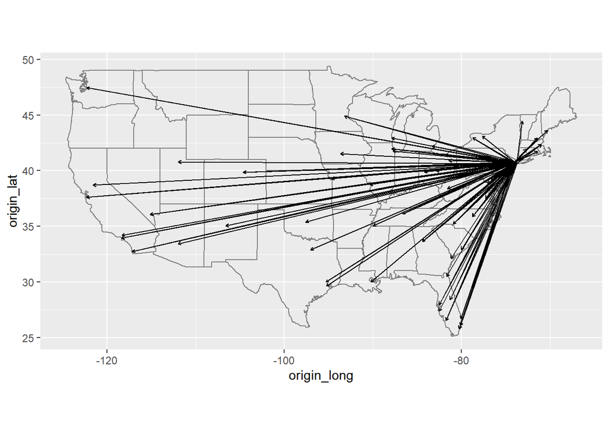

```r
flights_log_lat %>% slice_sample(n=250) %>% ggplot(aes(x=origin_long,xend=dest_lon,
                                                       y=origin_lat,yend=dest_lat)) +
   borders("state") + geom_segment(arrow=arrow(length = unit(0.1,'cm'))) + coord_quickmap()
```

2. A relação de weather e airports não foi marcada no diagrama como ela deve ser feita?

Airports faa é uma chave estrangeira para origin em weather.

3. Weather só contém informações para os aeroportos de NY, se registrasse informações para todos aeroportos, quais outras relações deveriam existir?

Caso weather registrasse para todos, deveria existir uma relação entre weather e dest.

4. Algumas datas do ano são especiais e menos pessoas boam nesse dias, como você poderia representar esses dados como dataframe. Quais seriam suas chaves primárias? Como se conectaria com outras?

Poderíamos criar um dataframe com as seguintes colunas:

- Dia = Chave Primária e conecta com Dia de outros df
- Mês = Chave Primária e conecta com Mês de outros df
- Motivo

## 13.3 Keys

As variáveis usadas para conectar cada tabela são chamadas de chaves. Uma chave é uma variável ou conjunto de variáveis que indentifica unicamente uma observação. Por exemplo, cada avião é unicamente indentificado pelo seu número de cauda. Para indentificar uma observação em weather por exemplo temos como chave : year, month, day, hour e origin.

Existem 2 tipos de chave?

- Uma chave primária indentifica unicamente uma observação na sua tabela. Por exemplo tailnum é uma chave primária de planes pois indentifica um avião unicamente.
- Uma chave estrangeira indentifica unicamente uma observação em outra tabela. flights$tailnum é uma chave estrangeira pois aparece em flights onde combinam com cada avião único.

Uma variável pode ser chave primária e chave estrangeira ao mesmo tempo.

Quando você indentificou uma chave primária podemos testar por meio de uma contagem.

```r
planes %>% count(tailnum) %>%  filter(n>1)
```

```
## # A tibble: 0 x 2
## # ... with 2 variables: tailnum <chr>, n <int>
```

```r
weather %>% count(origin,year,month,day,hour) %>%  filter(n>1)
```

```
## # A tibble: 3 x 6
##   origin  year month   day  hour     n
##   <chr>  <int> <int> <int> <int> <int>
## 1 EWR     2013    11     3     1     2
## 2 JFK     2013    11     3     1     2
## 3 LGA     2013    11     3     1     2
```

O que filtramos de weather é uma chave primária mas parece que houve um erro ao armazenar os dados do dia 3 de novembro as 1 hora. Com um banco de dados com chaves bem definidas isso seria evitado.

```r
airports %>% count(faa) %>% filter(n>1)
```

```
## # A tibble: 0 x 2
## # ... with 2 variables: faa <chr>, n <int>
```

Nem todos bancos de dados tem uma chave primária bem definida, por exemplo flights não tem uma chave primária bem definida. Caso isso aconteça podemos criar uma surrogate key que pode ser criada por meio de mutate() e row_number() e ser usada de primary key.

### Exercícios 13.3.1

1. Adicione uma surrogate key para voos.

```r
flights %>% mutate(voo_id = row_number()) %>% select(voo_id,everything())
```

```
## # A tibble: 336,776 x 20
##    voo_id  year month   day dep_time sched_dep_time dep_delay arr_time
##     <int> <int> <int> <int>    <int>          <int>     <dbl>    <int>
##  1      1  2013     1     1      517            515         2      830
##  2      2  2013     1     1      533            529         4      850
##  3      3  2013     1     1      542            540         2      923
##  4      4  2013     1     1      544            545        -1     1004
##  5      5  2013     1     1      554            600        -6      812
##  6      6  2013     1     1      554            558        -4      740
##  7      7  2013     1     1      555            600        -5      913
##  8      8  2013     1     1      557            600        -3      709
##  9      9  2013     1     1      557            600        -3      838
## 10     10  2013     1     1      558            600        -2      753
## # ... with 336,766 more rows, and 12 more variables: sched_arr_time <int>,
## #   arr_delay <dbl>, carrier <chr>, flight <int>, tailnum <chr>, origin <chr>,
## #   dest <chr>, air_time <dbl>, distance <dbl>, hour <dbl>, minute <dbl>,
## #   time_hour <dttm>
```

2. Indentifique as chaves nos seguinte dataframes:

Lahman::Batting, babynames::babynames nasaweather::atmos fueleconomy::vehicles ggplot2::diamonds

```r
Lahman::Batting %>% count(playerID,yearID,stint) %>% filter(n>1)
```

```
## [1] playerID yearID   stint    n
## <0 rows> (or 0-length row.names)
```

PlayerId, YearId e stint são as chaves primárias.

```r
babynames::babynames %>% head
```

```
## # A tibble: 6 x 5
##    year sex   name          n   prop
##   <dbl> <chr> <chr>     <int>  <dbl>
## 1  1880 F     Mary       7065 0.0724
## 2  1880 F     Anna       2604 0.0267
## 3  1880 F     Emma       2003 0.0205
## 4  1880 F     Elizabeth  1939 0.0199
## 5  1880 F     Minnie     1746 0.0179
## 6  1880 F     Margaret   1578 0.0162
```

As chaves primárias year,sex e name.

```r
nasaweather::atmos %>% count(lat,long,year,month) %>% filter(n>1)
```

```
## # A tibble: 0 x 5
## # ... with 5 variables: lat <dbl>, long <dbl>, year <int>, month <int>, n <int>
```

As chaves primárias são lat, long, year e month.

```r
fueleconomy::vehicles %>% count(id) %>% filter(n>1)
```

```
## # A tibble: 0 x 2
## # ... with 2 variables: id <dbl>, n <int>
```

A chave primária é id.

```r
diamonds %>% nrow() - diamonds %>% distinct() %>% nrow()
```

```
## [1] 146
```

Podemos ver que temos 146 observações que tem um par idêntico, dessa forma não temos uma chave primária para esse dataset. Temos que criar uma surrogate key.

```r
diamonds %>% mutate(id_diamante = row_number()) %>% select(id_diamante,everything())
```

```
## # A tibble: 53,940 x 11
##    id_diamante carat cut       color clarity depth table price     x     y     z
##          <int> <dbl> <ord>     <ord> <ord>   <dbl> <dbl> <int> <dbl> <dbl> <dbl>
##  1           1  0.23 Ideal     E     SI2      61.5    55   326  3.95  3.98  2.43
##  2           2  0.21 Premium   E     SI1      59.8    61   326  3.89  3.84  2.31
##  3           3  0.23 Good      E     VS1      56.9    65   327  4.05  4.07  2.31
##  4           4  0.29 Premium   I     VS2      62.4    58   334  4.2   4.23  2.63
##  5           5  0.31 Good      J     SI2      63.3    58   335  4.34  4.35  2.75
##  6           6  0.24 Very Good J     VVS2     62.8    57   336  3.94  3.96  2.48
##  7           7  0.24 Very Good I     VVS1     62.3    57   336  3.95  3.98  2.47
##  8           8  0.26 Very Good H     SI1      61.9    55   337  4.07  4.11  2.53
##  9           9  0.22 Fair      E     VS2      65.1    61   337  3.87  3.78  2.49
## 10          10  0.23 Very Good H     VS1      59.4    61   338  4     4.05  2.39
## # ... with 53,930 more rows
```

## 13.4 Mutating Joins

A primeira ferramenta que olharemos será mutating join. Essa função permite combinar variáveis de duas tabelas. Primeiro combina as observações pelas chaves, então copia pelas variáveis de uma tabela para a outra.

Assim como mutate(), a função join adiciona variáveis a direita.

```r
(flights2 <- flights %>%
  select(year:day, hour, origin, dest, tailnum, carrier))
```

```
## # A tibble: 336,776 x 8
##     year month   day  hour origin dest  tailnum carrier
##    <int> <int> <int> <dbl> <chr>  <chr> <chr>   <chr>
##  1  2013     1     1     5 EWR    IAH   N14228  UA
##  2  2013     1     1     5 LGA    IAH   N24211  UA
##  3  2013     1     1     5 JFK    MIA   N619AA  AA
##  4  2013     1     1     5 JFK    BQN   N804JB  B6
##  5  2013     1     1     6 LGA    ATL   N668DN  DL
##  6  2013     1     1     5 EWR    ORD   N39463  UA
##  7  2013     1     1     6 EWR    FLL   N516JB  B6
##  8  2013     1     1     6 LGA    IAD   N829AS  EV
##  9  2013     1     1     6 JFK    MCO   N593JB  B6
## 10  2013     1     1     6 LGA    ORD   N3ALAA  AA
## # ... with 336,766 more rows
```

```r
flights2 %>%
  select(-origin, -dest) %>%
  left_join(airlines, by = "carrier")
```

```
## # A tibble: 336,776 x 7
##     year month   day  hour tailnum carrier name
##    <int> <int> <int> <dbl> <chr>   <chr>   <chr>
##  1  2013     1     1     5 N14228  UA      United Air Lines Inc.
##  2  2013     1     1     5 N24211  UA      United Air Lines Inc.
##  3  2013     1     1     5 N619AA  AA      American Airlines Inc.
##  4  2013     1     1     5 N804JB  B6      JetBlue Airways
##  5  2013     1     1     6 N668DN  DL      Delta Air Lines Inc.
##  6  2013     1     1     5 N39463  UA      United Air Lines Inc.
##  7  2013     1     1     6 N516JB  B6      JetBlue Airways
##  8  2013     1     1     6 N829AS  EV      ExpressJet Airlines Inc.
##  9  2013     1     1     6 N593JB  B6      JetBlue Airways
## 10  2013     1     1     6 N3ALAA  AA      American Airlines Inc.
## # ... with 336,766 more rows
```

### 13.4.1 Understanding Joins

Vamos aprender um pouco sobre joins, é parecido com SQL.

```r
x <- tribble(
  ~key, ~val_x,
     1, "x1",
     2, "x2",
     3, "x3"
)
y <- tribble(
  ~key, ~val_y,
     1, "y1",
     2, "y2",
     4, "y3"
)
```

Joins vão ser junções baseados na chave.

### 13.4.2 Inner Join

A mais simples delas, o inner join junta tabelas quando suas chaves são iguais. O argumento by informa qual a chave.

```r
inner_join(x,y,by='key')
```

```
## # A tibble: 2 x 3
##     key val_x val_y
##   <dbl> <chr> <chr>
## 1     1 x1    y1
## 2     2 x2    y2
```

Linhas que não são combinadas são descartadas.

### 13.4.3 Outer Joins

Enquanto inner joins mantém observações que estão nas duas tabelas. Outer Joins mantém as que estão em pelo menos uma.

- left_join() mantém as observações de x
- right_join() mantém as observações de y
- full_join() mantém as observações de x e y

Os locais que não são completos, a chave não encontra par são tratados como NA

```r
left_join(x,y,by='key')
```

```
## # A tibble: 3 x 3
##     key val_x val_y
##   <dbl> <chr> <chr>
## 1     1 x1    y1
## 2     2 x2    y2
## 3     3 x3    <NA>
```

```r
right_join(x,y,by='key')
```

```
## # A tibble: 3 x 3
##     key val_x val_y
##   <dbl> <chr> <chr>
## 1     1 x1    y1
## 2     2 x2    y2
## 3     4 <NA>  y3
```

```r
full_join(x,y,by='key')
```

```
## # A tibble: 4 x 3
##     key val_x val_y
##   <dbl> <chr> <chr>
## 1     1 x1    y1
## 2     2 x2    y2
## 3     3 x3    <NA>
## 4     4 <NA>  y3
```

### 13.4.3 Duplicate Keys

E se as chaves não forem únicas? Existem duas possibilidades.

1 - Quando uma tabela tem chaves repetidas: Comum quando temos relações um para muitos e queremos informações extra.

```r
x <- tribble(
  ~key, ~val_x,
     1, "x1",
     2, "x2",
     2, "x3",
     1, "x4"
)
y <- tribble(
  ~key, ~val_y,
     1, "y1",
     2, "y2"
)
left_join(x, y, by = "key")
```

```
## # A tibble: 4 x 3
##     key val_x val_y
##   <dbl> <chr> <chr>
## 1     1 x1    y1
## 2     2 x2    y2
## 3     2 x3    y2
## 4     1 x4    y1
```

2 - Ambas tabelas tem chaves repetidas. Quando fazemos isso obtemos um produto cartesiano. Todas combinações dos locais onde aquelas chaves estão presentes.

```r
x <- tribble(
  ~key, ~val_x,
     1, "x1",
     2, "x2",
     2, "x3",
     3, "x4"
)
y <- tribble(
  ~key, ~val_y,
     1, "y1",
     2, "y2",
     2, "y3",
     3, "y4"
)
left_join(x, y, by = "key")
```

```
## # A tibble: 6 x 3
##     key val_x val_y
##   <dbl> <chr> <chr>
## 1     1 x1    y1
## 2     2 x2    y2
## 3     2 x2    y3
## 4     2 x3    y2
## 5     2 x3    y3
## 6     3 x4    y4
```

### 13.4.5 Defining the Key Columns

Até agora as tabelas foram combinadas por uma só coluna de cada e elas tinham o mesmo nome. Mas em situações reais esse não é o caso normalmente. Então usamos o argumento by para conectar de outra maneira.

- O default: by= NULL usa todas as variáveis que tem o mesmo nome nas duas tabelas. Natural Join.

```r
flights2 %>%
  left_join(weather)
```

```
## # A tibble: 336,776 x 18
##     year month   day  hour origin dest  tailnum carrier  temp  dewp humid
##    <int> <int> <int> <dbl> <chr>  <chr> <chr>   <chr>   <dbl> <dbl> <dbl>
##  1  2013     1     1     5 EWR    IAH   N14228  UA       39.0  28.0  64.4
##  2  2013     1     1     5 LGA    IAH   N24211  UA       39.9  25.0  54.8
##  3  2013     1     1     5 JFK    MIA   N619AA  AA       39.0  27.0  61.6
##  4  2013     1     1     5 JFK    BQN   N804JB  B6       39.0  27.0  61.6
##  5  2013     1     1     6 LGA    ATL   N668DN  DL       39.9  25.0  54.8
##  6  2013     1     1     5 EWR    ORD   N39463  UA       39.0  28.0  64.4
##  7  2013     1     1     6 EWR    FLL   N516JB  B6       37.9  28.0  67.2
##  8  2013     1     1     6 LGA    IAD   N829AS  EV       39.9  25.0  54.8
##  9  2013     1     1     6 JFK    MCO   N593JB  B6       37.9  27.0  64.3
## 10  2013     1     1     6 LGA    ORD   N3ALAA  AA       39.9  25.0  54.8
## # ... with 336,766 more rows, and 7 more variables: wind_dir <dbl>,
## #   wind_speed <dbl>, wind_gust <dbl>, precip <dbl>, pressure <dbl>,
## #   visib <dbl>, time_hour <dttm>
```

- Um vetor de caracteres: Funciona como o natural join porém nos selecionamos a coluna. flights e planes contém a variável ano porém elas tem significado diferente. Queremos juntar apenas por tailnum.

```r
flights2 %>% left_join(planes,by='tailnum')
```

```
## # A tibble: 336,776 x 16
##    year.x month   day  hour origin dest  tailnum carrier year.y type
##     <int> <int> <int> <dbl> <chr>  <chr> <chr>   <chr>    <int> <chr>
##  1   2013     1     1     5 EWR    IAH   N14228  UA        1999 Fixed wing mult~
##  2   2013     1     1     5 LGA    IAH   N24211  UA        1998 Fixed wing mult~
##  3   2013     1     1     5 JFK    MIA   N619AA  AA        1990 Fixed wing mult~
##  4   2013     1     1     5 JFK    BQN   N804JB  B6        2012 Fixed wing mult~
##  5   2013     1     1     6 LGA    ATL   N668DN  DL        1991 Fixed wing mult~
##  6   2013     1     1     5 EWR    ORD   N39463  UA        2012 Fixed wing mult~
##  7   2013     1     1     6 EWR    FLL   N516JB  B6        2000 Fixed wing mult~
##  8   2013     1     1     6 LGA    IAD   N829AS  EV        1998 Fixed wing mult~
##  9   2013     1     1     6 JFK    MCO   N593JB  B6        2004 Fixed wing mult~
## 10   2013     1     1     6 LGA    ORD   N3ALAA  AA          NA <NA>
## # ... with 336,766 more rows, and 6 more variables: manufacturer <chr>,
## #   model <chr>, engines <int>, seats <int>, speed <int>, engine <chr>
```

As variáveis com mesmo nome são diferenciadas por um sufixo

- Um vetor de caracteres nomeado. Vai fazer a combinação e manter os da tabela x no output.

```r
flights2 %>%
  left_join(airports, c("dest" = "faa"))
```

```
## # A tibble: 336,776 x 15
##     year month   day  hour origin dest  tailnum carrier name     lat   lon   alt
##    <int> <int> <int> <dbl> <chr>  <chr> <chr>   <chr>   <chr>  <dbl> <dbl> <dbl>
##  1  2013     1     1     5 EWR    IAH   N14228  UA      Georg~  30.0 -95.3    97
##  2  2013     1     1     5 LGA    IAH   N24211  UA      Georg~  30.0 -95.3    97
##  3  2013     1     1     5 JFK    MIA   N619AA  AA      Miami~  25.8 -80.3     8
##  4  2013     1     1     5 JFK    BQN   N804JB  B6      <NA>    NA    NA      NA
##  5  2013     1     1     6 LGA    ATL   N668DN  DL      Harts~  33.6 -84.4  1026
##  6  2013     1     1     5 EWR    ORD   N39463  UA      Chica~  42.0 -87.9   668
##  7  2013     1     1     6 EWR    FLL   N516JB  B6      Fort ~  26.1 -80.2     9
##  8  2013     1     1     6 LGA    IAD   N829AS  EV      Washi~  38.9 -77.5   313
##  9  2013     1     1     6 JFK    MCO   N593JB  B6      Orlan~  28.4 -81.3    96
## 10  2013     1     1     6 LGA    ORD   N3ALAA  AA      Chica~  42.0 -87.9   668
## # ... with 336,766 more rows, and 3 more variables: tz <dbl>, dst <chr>,
## #   tzone <chr>
```

```r
flights2 %>%
  left_join(airports, c("origin" = "faa"))
```

```
## # A tibble: 336,776 x 15
##     year month   day  hour origin dest  tailnum carrier name     lat   lon   alt
##    <int> <int> <int> <dbl> <chr>  <chr> <chr>   <chr>   <chr>  <dbl> <dbl> <dbl>
##  1  2013     1     1     5 EWR    IAH   N14228  UA      Newar~  40.7 -74.2    18
##  2  2013     1     1     5 LGA    IAH   N24211  UA      La Gu~  40.8 -73.9    22
##  3  2013     1     1     5 JFK    MIA   N619AA  AA      John ~  40.6 -73.8    13
##  4  2013     1     1     5 JFK    BQN   N804JB  B6      John ~  40.6 -73.8    13
##  5  2013     1     1     6 LGA    ATL   N668DN  DL      La Gu~  40.8 -73.9    22
##  6  2013     1     1     5 EWR    ORD   N39463  UA      Newar~  40.7 -74.2    18
##  7  2013     1     1     6 EWR    FLL   N516JB  B6      Newar~  40.7 -74.2    18
##  8  2013     1     1     6 LGA    IAD   N829AS  EV      La Gu~  40.8 -73.9    22
##  9  2013     1     1     6 JFK    MCO   N593JB  B6      John ~  40.6 -73.8    13
## 10  2013     1     1     6 LGA    ORD   N3ALAA  AA      La Gu~  40.8 -73.9    22
## # ... with 336,766 more rows, and 3 more variables: tz <dbl>, dst <chr>,
## #   tzone <chr>
```

### Exercícios 13.4.6

1. Calcule o delay médio por destino depois junte com aeroportos para mostrar a distribuição espacial dos atrasos.

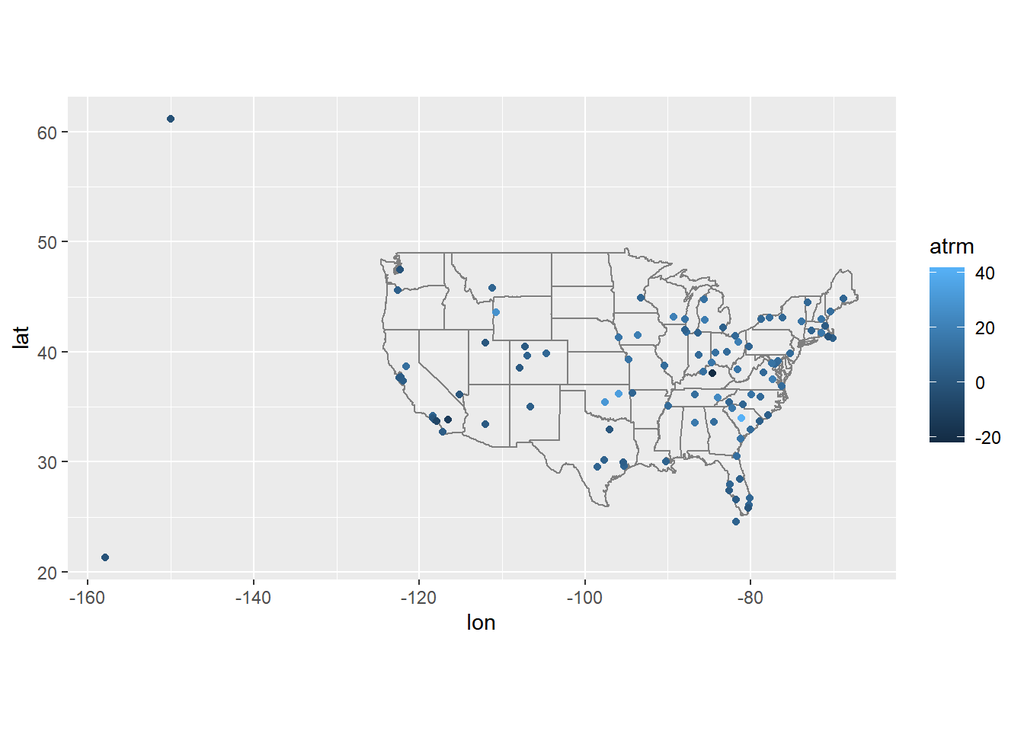

```r
flights %>% group_by(dest) %>% summarise(atrm = mean(arr_delay,na.rm = T)) %>% left_join(airports,by=c('dest'='faa')) %>% filter(!is.na(lat)) %>% ggplot(aes(lon,lat)) + borders('state') +geom_point(aes(color=atrm)) + coord_quickmap()
```

2. Adicione as coordenadas do destino e origem ao flights.

```r
flights %>% select(month:dest) %>% left_join(select(airports,faa,lat,lon),by=c('origin'='faa')) %>% left_join(select(airports,faa,lat,lon),by=c('dest'='faa'),suffix=c('_origin','_dest'))
```

```
## # A tibble: 336,776 x 17
##    month   day dep_time sched_dep_time dep_delay arr_time sched_arr_time
##    <int> <int>    <int>          <int>     <dbl>    <int>          <int>
##  1     1     1      517            515         2      830            819
##  2     1     1      533            529         4      850            830
##  3     1     1      542            540         2      923            850
##  4     1     1      544            545        -1     1004           1022
##  5     1     1      554            600        -6      812            837
##  6     1     1      554            558        -4      740            728
##  7     1     1      555            600        -5      913            854
##  8     1     1      557            600        -3      709            723
##  9     1     1      557            600        -3      838            846
## 10     1     1      558            600        -2      753            745
## # ... with 336,766 more rows, and 10 more variables: arr_delay <dbl>,
## #   carrier <chr>, flight <int>, tailnum <chr>, origin <chr>, dest <chr>,
## #   lat_origin <dbl>, lon_origin <dbl>, lat_dest <dbl>, lon_dest <dbl>
```

3. Existe uma relação entre a idade do avião e seus atrasos?

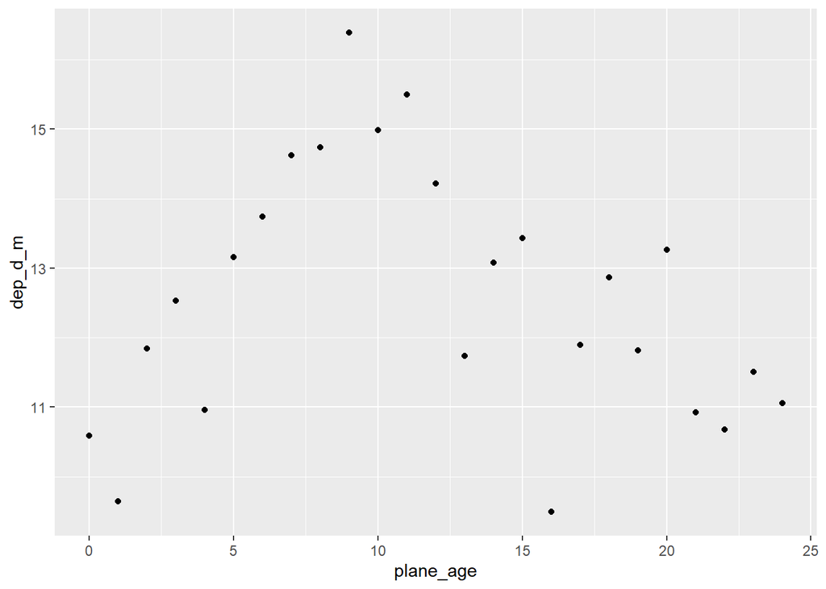

```r
flights %>% left_join(planes,by='tailnum',suffix=c('_fl','_plane')) %>% mutate(plane_age = year_fl-year_plane) %>% filter(plane_age < 25) %>% group_by(plane_age) %>% summarise(dep_d_m = mean(dep_delay,na.rm = T),arr_d_m = mean(arr_delay,na.rm=T)) %>% ggplot(aes(plane_age,dep_d_m)) + geom_point()
```

4. Qual condição aérea torna mais provável os atrasos.

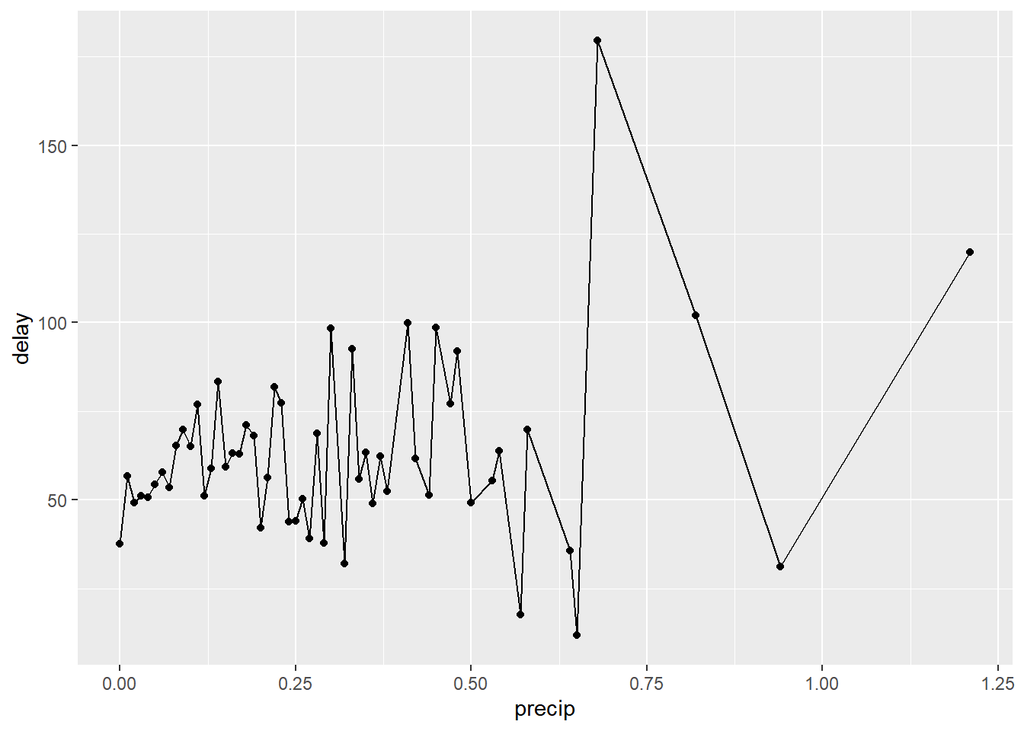

```r
flights %>% select(year,month,day,hour,origin,dep_delay) %>% filter(dep_delay>0) %>% left_join(weather) %>%
  group_by(precip) %>%
  summarise(delay = mean(dep_delay, na.rm = TRUE)) %>%
  ggplot(aes(x = precip, y = delay)) +
  geom_line() + geom_point()
```

## 13.5 Filtering Joins

Joins de filtro combinam observações da mesma maneira que mutating joins, mas afeta as observações, não as variáveis. Existem dois tipos:

- semi_join() : mantém todas observações de x que tem uma combinação em y.
- anti_join() : descarta todas observações de x que tem uma combinação em y.

semi joins são úteis para recombinar sumarios com seus dados originais. Ex: Imagine que queremos descobrimos os dez destinos mais populares:

```r
(populares <- flights %>% count(dest,sort=T) %>% head(10))
```

```
## # A tibble: 10 x 2
##    dest      n
##    <chr> <int>
##  1 ORD   17283
##  2 ATL   17215
##  3 LAX   16174
##  4 BOS   15508
##  5 MCO   14082
##  6 CLT   14064
##  7 SFO   13331
##  8 FLL   12055
##  9 MIA   11728
## 10 DCA    9705
```

Agora imagine que você queira descobrir todos os voos que foram para esses locais, você poderia construir um filtro manualmetne:

```r
flights %>% filter(dest %in% populares$dest)
```

```
## # A tibble: 141,145 x 19
##     year month   day dep_time sched_dep_time dep_delay arr_time sched_arr_time
##    <int> <int> <int>    <int>          <int>     <dbl>    <int>          <int>
##  1  2013     1     1      542            540         2      923            850
##  2  2013     1     1      554            600        -6      812            837
##  3  2013     1     1      554            558        -4      740            728
##  4  2013     1     1      555            600        -5      913            854
##  5  2013     1     1      557            600        -3      838            846
##  6  2013     1     1      558            600        -2      753            745
##  7  2013     1     1      558            600        -2      924            917
##  8  2013     1     1      558            600        -2      923            937
##  9  2013     1     1      559            559         0      702            706
## 10  2013     1     1      600            600         0      851            858
## # ... with 141,135 more rows, and 11 more variables: arr_delay <dbl>,
## #   carrier <chr>, flight <int>, tailnum <chr>, origin <chr>, dest <chr>,
## #   air_time <dbl>, distance <dbl>, hour <dbl>, minute <dbl>, time_hour <dttm>
```

Porém isso se torna mais complexo quando a contagem foi com mais variáveis por exemplo. Podemos usar um semojoin para isso.

```r
flights %>% semi_join(populares)
```

```
## # A tibble: 141,145 x 19
##     year month   day dep_time sched_dep_time dep_delay arr_time sched_arr_time
##    <int> <int> <int>    <int>          <int>     <dbl>    <int>          <int>
##  1  2013     1     1      542            540         2      923            850
##  2  2013     1     1      554            600        -6      812            837
##  3  2013     1     1      554            558        -4      740            728
##  4  2013     1     1      555            600        -5      913            854
##  5  2013     1     1      557            600        -3      838            846
##  6  2013     1     1      558            600        -2      753            745
##  7  2013     1     1      558            600        -2      924            917
##  8  2013     1     1      558            600        -2      923            937
##  9  2013     1     1      559            559         0      702            706
## 10  2013     1     1      600            600         0      851            858
## # ... with 141,135 more rows, and 11 more variables: arr_delay <dbl>,
## #   carrier <chr>, flight <int>, tailnum <chr>, origin <chr>, dest <chr>,
## #   air_time <dbl>, distance <dbl>, hour <dbl>, minute <dbl>, time_hour <dttm>
```

O inverso de um semi_join é um anti_join. Esse confere os dados e retorna as observações de x que não tiveram combinação em y.

Por exemplo, existem muitos aviões em flights que não estão registrados em planes.

```r
flights %>% anti_join(planes,by='tailnum') %>% count(tailnum,sort=T)
```

```
## # A tibble: 722 x 2
##    tailnum     n
##    <chr>   <int>
##  1 <NA>     2512
##  2 N725MQ    575
##  3 N722MQ    513
##  4 N723MQ    507
##  5 N713MQ    483
##  6 N735MQ    396
##  7 N0EGMQ    371
##  8 N534MQ    364
##  9 N542MQ    363
## 10 N531MQ    349
## # ... with 712 more rows
```

### Exercícios 13.5.1

1. O que significa um voo ter NA de tailnum? O que os aviões que não tem uma combinação em planes tem em comum?

Um voo que tem tailnum = NA é um voo que foi cancelado.

```r
flights %>% anti_join(planes,by='tailnum') %>% filter(is.na(tailnum))
```

```
## # A tibble: 2,512 x 19
##     year month   day dep_time sched_dep_time dep_delay arr_time sched_arr_time
##    <int> <int> <int>    <int>          <int>     <dbl>    <int>          <int>
##  1  2013     1     2       NA           1545        NA       NA           1910
##  2  2013     1     2       NA           1601        NA       NA           1735
##  3  2013     1     3       NA            857        NA       NA           1209
##  4  2013     1     3       NA            645        NA       NA            952
##  5  2013     1     4       NA            845        NA       NA           1015
##  6  2013     1     4       NA           1830        NA       NA           2044
##  7  2013     1     5       NA            840        NA       NA           1001
##  8  2013     1     7       NA            820        NA       NA            958
##  9  2013     1     8       NA           1645        NA       NA           1838
## 10  2013     1     9       NA            755        NA       NA           1012
## # ... with 2,502 more rows, and 11 more variables: arr_delay <dbl>,
## #   carrier <chr>, flight <int>, tailnum <chr>, origin <chr>, dest <chr>,
## #   air_time <dbl>, distance <dbl>, hour <dbl>, minute <dbl>, time_hour <dttm>
```

O que os aviões que não tem uma combinação em planes tem em comum?

```r
flights %>% anti_join(planes,by='tailnum') %>% count(carrier,sort=T)
```

```
## # A tibble: 10 x 2
##    carrier     n
##    <chr>   <int>
##  1 MQ      25397
##  2 AA      22558
##  3 UA       1693
##  4 9E       1044
##  5 B6        830
##  6 US        699
##  7 FL        187
##  8 DL        110
##  9 F9         50
## 10 WN         38
```

90% dos aviões que não estão registrados em planes e voarão são das companhias MQ e AA. Não tenho certeza do motivo.

2. Filtre os voos para somente mostrar os que voaram com aviões que fizeram ao menos 100 voos.

Existem duas maneiras de fazer isso:

Semijoin:

```r
mais100 <- flights %>% count(tailnum) %>% filter(n>100)

flights %>% semi_join(mais100,by='tailnum')
```

```
## # A tibble: 229,202 x 19
##     year month   day dep_time sched_dep_time dep_delay arr_time sched_arr_time
##    <int> <int> <int>    <int>          <int>     <dbl>    <int>          <int>
##  1  2013     1     1      517            515         2      830            819
##  2  2013     1     1      533            529         4      850            830
##  3  2013     1     1      544            545        -1     1004           1022
##  4  2013     1     1      554            558        -4      740            728
##  5  2013     1     1      555            600        -5      913            854
##  6  2013     1     1      557            600        -3      709            723
##  7  2013     1     1      557            600        -3      838            846
##  8  2013     1     1      558            600        -2      849            851
##  9  2013     1     1      558            600        -2      853            856
## 10  2013     1     1      558            600        -2      923            937
## # ... with 229,192 more rows, and 11 more variables: arr_delay <dbl>,
## #   carrier <chr>, flight <int>, tailnum <chr>, origin <chr>, dest <chr>,
## #   air_time <dbl>, distance <dbl>, hour <dbl>, minute <dbl>, time_hour <dttm>
```

Mutate e groupby:

```r
flights %>% group_by(tailnum) %>% mutate(voosav = n()) %>% filter(voosav >100)
```

```
## # A tibble: 229,202 x 20
## # Groups:   tailnum [1,201]
##     year month   day dep_time sched_dep_time dep_delay arr_time sched_arr_time
##    <int> <int> <int>    <int>          <int>     <dbl>    <int>          <int>
##  1  2013     1     1      517            515         2      830            819
##  2  2013     1     1      533            529         4      850            830
##  3  2013     1     1      544            545        -1     1004           1022
##  4  2013     1     1      554            558        -4      740            728
##  5  2013     1     1      555            600        -5      913            854
##  6  2013     1     1      557            600        -3      709            723
##  7  2013     1     1      557            600        -3      838            846
##  8  2013     1     1      558            600        -2      849            851
##  9  2013     1     1      558            600        -2      853            856
## 10  2013     1     1      558            600        -2      923            937
## # ... with 229,192 more rows, and 12 more variables: arr_delay <dbl>,
## #   carrier <chr>, flight <int>, tailnum <chr>, origin <chr>, dest <chr>,
## #   air_time <dbl>, distance <dbl>, hour <dbl>, minute <dbl>, time_hour <dttm>,
## #   voosav <int>
```

3. Combine fueleconomy::vehicles e fueleconomy::common para encontrar somente informações sobre os modelos mais comuns.

```r
fueleconomy::vehicles %>% semi_join(fueleconomy::common)
```

```
## # A tibble: 14,531 x 12
##       id make  model   year class   trans  drive     cyl displ fuel    hwy   cty
##    <dbl> <chr> <chr>  <dbl> <chr>   <chr>  <chr>   <dbl> <dbl> <chr> <dbl> <dbl>
##  1  1833 Acura Integ~  1986 Subcom~ Autom~ Front-~     4   1.6 Regu~    28    22
##  2  1834 Acura Integ~  1986 Subcom~ Manua~ Front-~     4   1.6 Regu~    28    23
##  3  3037 Acura Integ~  1987 Subcom~ Autom~ Front-~     4   1.6 Regu~    28    22
##  4  3038 Acura Integ~  1987 Subcom~ Manua~ Front-~     4   1.6 Regu~    28    23
##  5  4183 Acura Integ~  1988 Subcom~ Autom~ Front-~     4   1.6 Regu~    27    22
##  6  4184 Acura Integ~  1988 Subcom~ Manua~ Front-~     4   1.6 Regu~    28    23
##  7  5303 Acura Integ~  1989 Subcom~ Autom~ Front-~     4   1.6 Regu~    27    22
##  8  5304 Acura Integ~  1989 Subcom~ Manua~ Front-~     4   1.6 Regu~    28    23
##  9  6442 Acura Integ~  1990 Subcom~ Autom~ Front-~     4   1.8 Regu~    24    20
## 10  6443 Acura Integ~  1990 Subcom~ Manua~ Front-~     4   1.8 Regu~    26    21
## # ... with 14,521 more rows
```

4. Encontre as 48 horas com mais atrasos do ano, cruze com weather. Consegue ver padrões?

```r
(maioresatr <- flights %>% group_by(time_hour) %>% summarise(atraso = mean(dep_delay,na.rm = T)) %>% arrange(desc(atraso)) %>% head(48))
```

```
## # A tibble: 48 x 2
##    time_hour           atraso
##    <dttm>               <dbl>
##  1 2013-02-09 10:00:00   269
##  2 2013-04-10 22:00:00   176.
##  3 2013-04-10 20:00:00   170.
##  4 2013-04-10 21:00:00   168.
##  5 2013-04-10 23:00:00   159
##  6 2013-04-19 22:00:00   157
##  7 2013-07-28 19:00:00   156.
##  8 2013-04-10 19:00:00   152.
##  9 2013-02-09 09:00:00   151
## 10 2013-04-19 19:00:00   150.
## # ... with 38 more rows
```

```r
clima <- weather %>% semi_join(maioresatr)
```

Podemos ver que essas horas costumam estar juntas, atrasos grandes acarretam mais grandes atrasos. Vamos comparar alguns fatores climáticos desses horários com a média.

```r
clima %>% select(wind_speed,precip,visib) %>% summary
```

```
##    wind_speed         precip            visib
##  Min.   : 0.000   Min.   :0.00000   Min.   : 0.060
##  1st Qu.: 8.055   1st Qu.:0.00000   1st Qu.: 6.500
##  Median :12.659   Median :0.00000   Median :10.000
##  Mean   :13.190   Mean   :0.03154   Mean   : 7.789
##  3rd Qu.:17.262   3rd Qu.:0.01000   3rd Qu.:10.000
##  Max.   :33.373   Max.   :0.68000   Max.   :10.000
```

```r
weather %>% select(wind_speed,precip,visib) %>% summary
```

```
##    wind_speed           precip             visib
##  Min.   :   0.000   Min.   :0.000000   Min.   : 0.000
##  1st Qu.:   6.905   1st Qu.:0.000000   1st Qu.:10.000
##  Median :  10.357   Median :0.000000   Median :10.000
##  Mean   :  10.518   Mean   :0.004469   Mean   : 9.255
##  3rd Qu.:  13.809   3rd Qu.:0.000000   3rd Qu.:10.000
##  Max.   :1048.361   Max.   :1.210000   Max.   :10.000
##  NA's   :4
```

Podemos ver que a média de visibilade, precipitação e wind_speed é significativamente diferente do resto da amostra

```r
climared <- anti_join(weather,clima)
t.test(clima$visib,climared$visib)
```

```
##
##  Welch Two Sample t-test
##
## data:  clima$visib and climared$visib
## t = -5.5452, df = 142.65, p-value = 1.381e-07
## alternative hypothesis: true difference in means is not equal to 0
## 95 percent confidence interval:
##  -2.0002124 -0.9489181
## sample estimates:
## mean of x mean of y
##  7.788881  9.263446
```

```r
t.test(clima$wind_speed,climared$wind_speed)
```

```
##
##  Welch Two Sample t-test
##
## data:  clima$wind_speed and climared$wind_speed
## t = 4.491, df = 144.26, p-value = 1.441e-05
## alternative hypothesis: true difference in means is not equal to 0
## 95 percent confidence interval:
##  1.504386 3.869486
## sample estimates:
## mean of x mean of y
##  13.18971  10.50277
```

```r
t.test(clima$precip,climared$precip)
```

```
##
##  Welch Two Sample t-test
##
## data:  clima$precip and climared$precip
## t = 4.0368, df = 142.21, p-value = 8.818e-05
## alternative hypothesis: true difference in means is not equal to 0
## 95 percent confidence interval:
##  0.01388989 0.04054696
## sample estimates:
##   mean of x   mean of y
## 0.031538462 0.004320037
```

5. What does anti_join(flights, airports, by = c(“dest” = “faa”)) tell you? What does anti_join(airports, flights, by = c(“faa” = “dest”)) tell you?

```r
anti_join(flights, airports, by = c("dest" = "faa"))
```

```
## # A tibble: 7,602 x 19
##     year month   day dep_time sched_dep_time dep_delay arr_time sched_arr_time
##    <int> <int> <int>    <int>          <int>     <dbl>    <int>          <int>
##  1  2013     1     1      544            545        -1     1004           1022
##  2  2013     1     1      615            615         0     1039           1100
##  3  2013     1     1      628            630        -2     1137           1140
##  4  2013     1     1      701            700         1     1123           1154
##  5  2013     1     1      711            715        -4     1151           1206
##  6  2013     1     1      820            820         0     1254           1310
##  7  2013     1     1      820            820         0     1249           1329
##  8  2013     1     1      840            845        -5     1311           1350
##  9  2013     1     1      909            810        59     1331           1315
## 10  2013     1     1      913            918        -5     1346           1416
## # ... with 7,592 more rows, and 11 more variables: arr_delay <dbl>,
## #   carrier <chr>, flight <int>, tailnum <chr>, origin <chr>, dest <chr>,
## #   air_time <dbl>, distance <dbl>, hour <dbl>, minute <dbl>, time_hour <dttm>
```

Essa operação nos mostra os voos que foram para destinos não registrados na table aeroportos.

```r
anti_join(airports, flights, by = c("faa" = "dest"))
```

```
## # A tibble: 1,357 x 8
##    faa   name                       lat    lon   alt    tz dst   tzone
##    <chr> <chr>                    <dbl>  <dbl> <dbl> <dbl> <chr> <chr>
##  1 04G   Lansdowne Airport         41.1  -80.6  1044    -5 A     America/New_Yo~
##  2 06A   Moton Field Municipal A~  32.5  -85.7   264    -6 A     America/Chicago
##  3 06C   Schaumburg Regional       42.0  -88.1   801    -6 A     America/Chicago
##  4 06N   Randall Airport           41.4  -74.4   523    -5 A     America/New_Yo~
##  5 09J   Jekyll Island Airport     31.1  -81.4    11    -5 A     America/New_Yo~
##  6 0A9   Elizabethton Municipal ~  36.4  -82.2  1593    -5 A     America/New_Yo~
##  7 0G6   Williams County Airport   41.5  -84.5   730    -5 A     America/New_Yo~
##  8 0G7   Finger Lakes Regional A~  42.9  -76.8   492    -5 A     America/New_Yo~
##  9 0P2   Shoestring Aviation Air~  39.8  -76.6  1000    -5 U     America/New_Yo~
## 10 0S9   Jefferson County Intl     48.1 -123.    108    -8 A     America/Los_An~
## # ... with 1,347 more rows
```

Essa operação nos mostra os locais registrados que não foram destinos de voos.

6. You might expect that there’s an implicit relationship between plane and airline, because each plane is flown by a single airline. Confirm or reject this hypothesis using the tools you’ve learned above.

Vamos encontrar todas combinações de aviões e companhias.

```r
flights %>% filter(!is.na(tailnum)) %>% distinct(tailnum,carrier)
```

```
## # A tibble: 4,060 x 2
##    carrier tailnum
##    <chr>   <chr>
##  1 UA      N14228
##  2 UA      N24211
##  3 AA      N619AA
##  4 B6      N804JB
##  5 DL      N668DN
##  6 UA      N39463
##  7 B6      N516JB
##  8 EV      N829AS
##  9 B6      N593JB
## 10 AA      N3ALAA
## # ... with 4,050 more rows
```

Agora vamos ver os aviões que voaram por 2 companhias.

```r
(avioesduplos <- flights %>% filter(!is.na(tailnum)) %>% distinct(tailnum,carrier) %>% count(tailnum) %>% filter(n>1))
```

```
## # A tibble: 17 x 2
##    tailnum     n
##    <chr>   <int>
##  1 N146PQ      2
##  2 N153PQ      2
##  3 N176PQ      2
##  4 N181PQ      2
##  5 N197PQ      2
##  6 N200PQ      2
##  7 N228PQ      2
##  8 N232PQ      2
##  9 N933AT      2
## 10 N935AT      2
## 11 N977AT      2
## 12 N978AT      2
## 13 N979AT      2
## 14 N981AT      2
## 15 N989AT      2
## 16 N990AT      2
## 17 N994AT      2
```

Podemos ver que 17 aviões voaram por duas companhias aéreas

```r
flights %>% semi_join(avioesduplos) %>% select(carrier) %>% left_join(airlines) %>% count(name)
```

```
## # A tibble: 4 x 2
##   name                            n
##   <chr>                       <int>
## 1 AirTran Airways Corporation   168
## 2 Delta Air Lines Inc.          376
## 3 Endeavor Air Inc.              48
## 4 ExpressJet Airlines Inc.      232
```

Podemos ver que apenas essas 4 companhias contiveram aviões que voaram por mais de uma. É possível que uma tenha vendido aviões para a outra em pares ou uma delas vendeu para as outras.

## 13.6 Join Problems

Devemos fazer algumas coisas antes de começar a combinar caso nossos dados não estrjam da maneira ideal devemos tratalos.

Start by identifying the variables that form the primary key in each table. You should usually do this based on your understanding of the data, not empirically by looking for a combination of variables that give a unique identifier. If you just look for variables without thinking about what they mean, you might get (un)lucky and find a combination that’s unique in your current data but the relationship might not be true in general.

For example, the altitude and longitude uniquely identify each airport, but they are not good identifiers!

Check that your foreign keys match primary keys in another table. The best way to do this is with an anti_join(). It’s common for keys not to match because of data entry errors. Fixing these is often a lot of work.

## 13.7 Set Operations

Essas operações são feitas quando estamos comparando duas tabelas que contém variáveis iguais e podem conter observações iguais.

- intersect(x,y) = Retorna observações presentes em x e y
- union(x,y) = Retorna observações presentes em x ou y, repetidas são tratadas como uma.
- setdiff(x,y) = retorna observações em x mas que não estão em y.

```r
df1 <- tribble(
  ~x, ~y,
   1,  1,
   2,  1
)
df2 <- tribble(
  ~x, ~y,
   1,  1,
   1,  2
)
```

```r
intersect(df1,df2)
```

```
## # A tibble: 1 x 2
##       x     y
##   <dbl> <dbl>
## 1     1     1
```

```r
union(df1,df2)
```

```
## # A tibble: 3 x 2
##       x     y
##   <dbl> <dbl>
## 1     1     1
## 2     2     1
## 3     1     2
```

```r
setdiff(df1,df2)
```

```
## # A tibble: 1 x 2
##       x     y
##   <dbl> <dbl>
## 1     2     1
```

```r
setdiff(df2,df1)
```

```
## # A tibble: 1 x 2
##       x     y
##   <dbl> <dbl>
## 1     1     2
```